# Milestone 3

### Question 2: Tracking Seniors over Time

Looking at data from the Macalester Athletics website (rather than the Google Sheets data), can we track the seniors and how they’ve played over time? Have their average stats improved over time?

**SENIORS:** **Stepanie Geber** - 4 yr starter, **Adisa Preston** - 4 yr starter, **Gwen Wooten** - Started 1st year and 2nd year, **Nicole Norton** - started 1st, some of 2nd and 3rd and now starting in her 4th year, **Grace Galer** - starting in her senior year, **Torrance Williams** - 4 yr starter- Passing, **Jill MacInnis** - has never started but played in a number of matches in her 4 years

- Step 1: Import the data from the Macalester Athletics website for the past 4 years (2024, 2023, 2022, 2021)
- Step 2: Filter the data to only include the seniors
- Step 3: Calculate the average stats for each senior for each year
- Step 4: Make appropriate visualizations to see any trends

```r
library(tidyverse)
library(rvest)
library(janitor)
```

```r
year_links <- str_c("https://athletics.macalester.edu/sports/womens-volleyball/stats/", c(2021, 2022, 2023, 2024))

seniors <- c("Wooten, Gwen", "Preston, Adisa", "Geber, Stephanie", "Norton, Nicole", "Galer, Grace", "Williams, Torrance", "MacInnis, Jill")

year_to_df <- function(link){
  all_tables <- read_html(link) %>%
    html_table()

  tables <- c(all_tables[2], all_tables[3])
  cleaner_tables <- map(tables, ~ as.data.frame(.x) %>% row_to_names(1) %>% select(-c(`#`, `Bio Link`)))

  return_tables <- cleaner_tables[[1]] %>%
    left_join(cleaner_tables[[2]], by = join_by("Player", "SP")) %>%
    mutate(
      year = str_sub(link, nchar(link) - 3),
      Player = str_extract(Player, ".*")) %>%
    filter(Player %in% seniors)

  return(return_tables)
}

full_senior_stats <- map(year_links, year_to_df) %>%
  list_rbind()
```

```r
starters = c("Geber, Stephanie", "Preston, Adisa", "Williams, Torrance")

clean_senior_stats <- full_senior_stats %>%
  filter(Player %in% starters) %>%
  mutate(across(!Player, as.numeric))
```

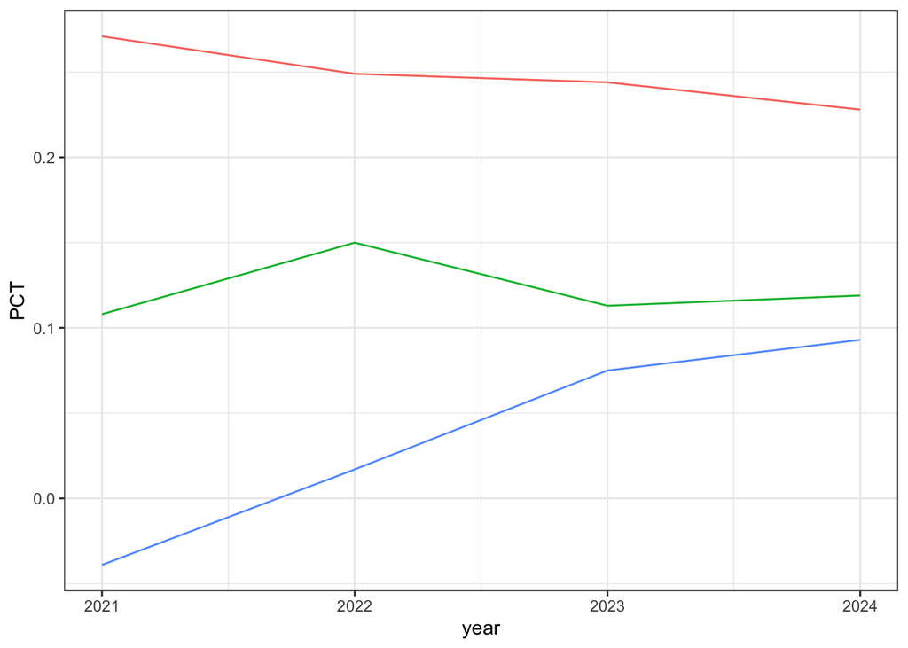

```r
per_year_lines <- function(yvar){
  clean_senior_stats %>%
    ggplot(aes(x = year, y = {{yvar}}, color = Player)) +
    geom_line(show.legend = FALSE) +
    theme_bw()
}

per_year_lines(PCT)
```

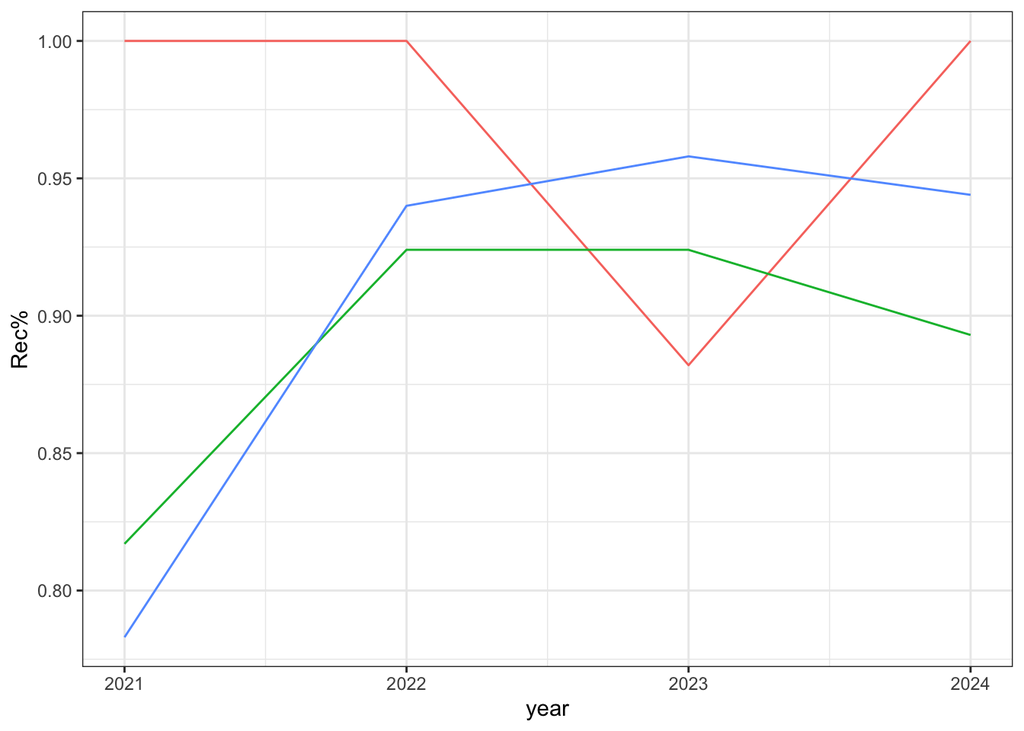

```r
per_year_lines(`Rec%`)
```